# Power

## Power

Power is the probability of rejecting the null hypothesis when it is false. The type II error is failing to reject the null hypothesis when it’s false; the probability of a type II error is usually called $\beta$. Therefore,
$$Power = 1-\beta$$

### Power and mean

- $H_0 : \mu =30$ versus $H_a :\mu >30$
- Then power is
  $$P(\frac{\overline{X}-30}{s/\sqrt{n}}>t_{1-\alpha, n-1}; \mu=\mu_a)$$
- Note that this is a function that depends on the specific value of $\mu_a$
- As $\mu_a$ approaches 30, the power approaches $\alpha$.
- For this example, we reject if $\frac{\overline{X}-30}{\sigma/\sqrt{n}}>z_{1-\alpha}$, or $\overline{X}>30+z_{1-\alpha}\frac{\sigma}{\sqrt{n}}$
- Under $H_0:\overline{X}\sim N(\mu_0,\sigma^2/n)$
- Under $H_0:\overline{X}\sim N(\mu_a,\sigma^2/n)$

```r
mu0<-30
mua<-32
n<-16
sigma<-4
alpha<-0.05
z <- qnorm(1-alpha)
pnorm(mu0+z*sigma/sqrt(n), mean = mu0, sd=sigma/sqrt(n), lower.tail=FALSE)
```

```
## [1] 0.05
```

```r
pnorm(mu0+z*sigma/sqrt(n), mean = mua, sd=sigma/sqrt(n), lower.tail=FALSE)
```

```
## [1] 0.63876
```

We can observe that power gets larger when mean is away from 30.

### Power and sample size, n

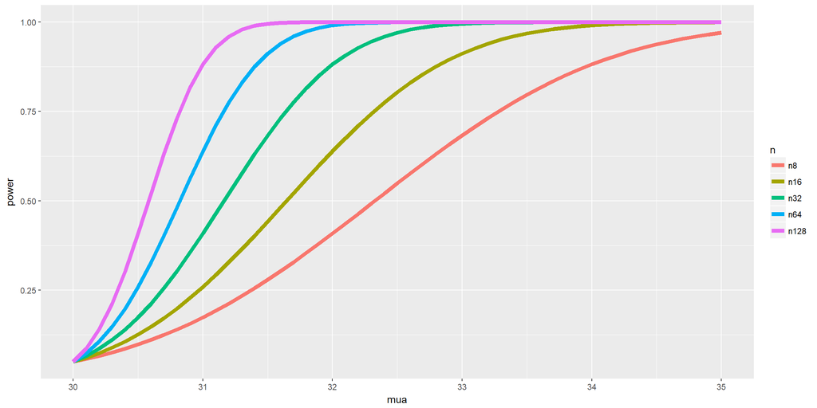

```r
nseq <- c(8, 16, 32, 64, 128)
mua <- seq(30, 35, by = 0.1)
z <- qnorm(.95)
power <- sapply(nseq, function(n)
pnorm(mu0 + z * sigma / sqrt(n), mean = mua, sd = sigma / sqrt(n),
          lower.tail = FALSE)
    )
colnames(power) <- paste("n", nseq, sep = "")
d <- data.frame(mua, power)
d2 <- melt(d, id.vars = "mua")
names(d2) <- c("mua", "n", "power")
g <- ggplot(d2,
            aes(x = mua, y = power, col = n)) + geom_line(size = 2)
g
```

We can observe that power increase as mua or n increases.

### Power and other factors

- Assuming everything is the same. When alpha decreases, power also decreases and type II error rate goes up (but type I error rate goes down).
- When sigma decreases, power increases and type II error rate goes down (type I error rate stays the same). This means that if the sample has a lot of noise, the power will be lower.

### Usage of power

- When testing $H_a :\mu > \mu_0$, notice if power is $1-\beta$, then
  $$1-\beta = P(\overline{X}>\mu_0+z_{1-\alpha}\frac{\sigma}{\sqrt{n}}; \mu=\mu_a)$$
- where $\overline{X} \sim N(\mu_a, \sigma^2/n)$
- Unknowns: $\mu_a, \sigma, n, \beta$
- Knowns: $\mu_0, \alpha$
- If any 3 of the unknowns are specified, we can solve for the unknown remainder.